# Week 5, machine learning

Ane Kleiven

2024-10-03

### Answers to questions **1. A biologist has just read an article about machine learning and decided to try it on his RNA-Seq data. Since he has many more genes than samples, he decided to do feature selection by choosing the most differentially expressed genes. He did feature selection first on the entire dataset and then validated his model using cross validation. To his dismay the analysis was heavily critiqued by the reviewers. They said he had to use an independent test set. The biologist doesn’t understand the criticism and comes to you. Explain to him what he did wrong and why. Write at most 250 words.** The biologist starts the whole process by doing feature selection on the whole data set, and identifying the DE genes. He now has a data set with fewer features. In the next step, the biologist divides the data set into one test set and one training set for doing cross validation. Cross validation is a method where you train and validate the model multiple times, with different combinations of test data and training data. The biologist should have divided the data into a training set and test set before he started feature selection. In this case, the model has already seen the test data (in the feature selection) when doing cross validation. When doing machine learning, you train your model first and then test it on unseen data. You do not look at your test data upon testing, the test data must be unseen. In the approach the biologist uses, it’s going to look like the model works (because the model has already seen the data). We can say that the model is cheating, the cross-validation process is biased. **2. Let’s say you want to “read” the genome sequence using machine learning. You figure you can use GWAS populations as training data with SNPs as features and traits as labels. Will this approach fly? Discuss using concepts such as omnigenics, curse of dimensionality, model complexity and overfitting. Write at most 250 words.** In the approach described above, you look at all the SNPs at the same time. Every SNP is important, so by doing this you are taking Omnigenics seriously. The principle of Omnigenics is that there are a lot of genes responsible for the heritability of traits. This means that you must look at many SNPs to describe heritability of traits. This makes it difficult to reduce the features in the model. One of the biggest issues with the Omnigenics approach, is “the curse of dimensionality”. Due to the millions of SNPs, you would also need millions of observations (samples) to describe the traits. The biggest research projects performed included a couple of hundred thousands samples, but have can we collect millions? There aren’t even that many persons on the planet. The model described would be extremely complex. Since many traits depend on many SNPs, there would be millions of interactions between the SNPs – making the model even more complex. The last issue with the model is overfitting, caused by too many features in relation to traits. A model that is too complex can also lead to overfitting. Overfitting means that the model becomes kind of a look up table for the training data, which doesn’t work for generalized data. Instead of predicting, the model memorizes.

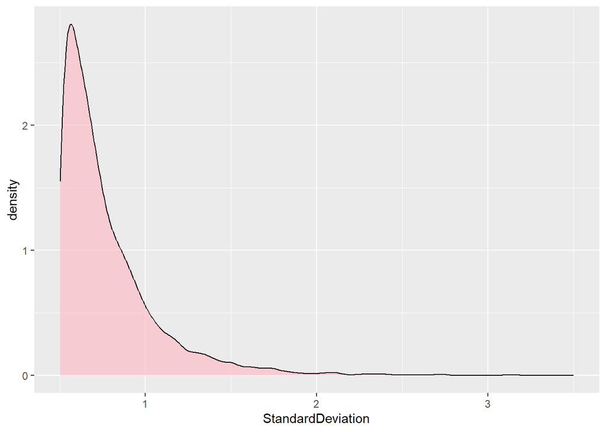

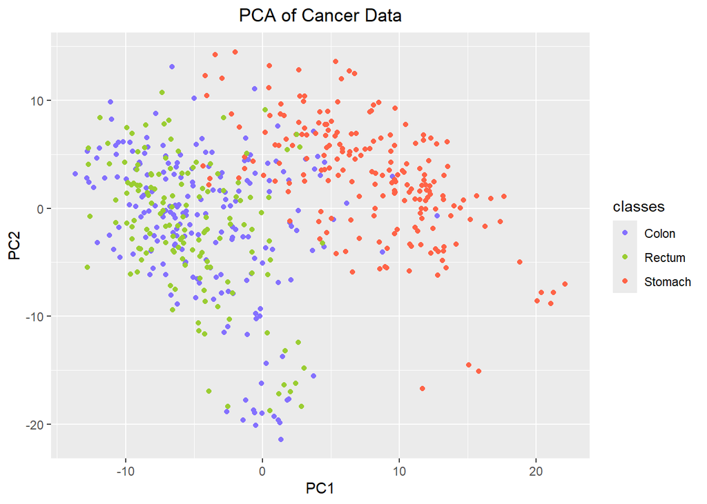

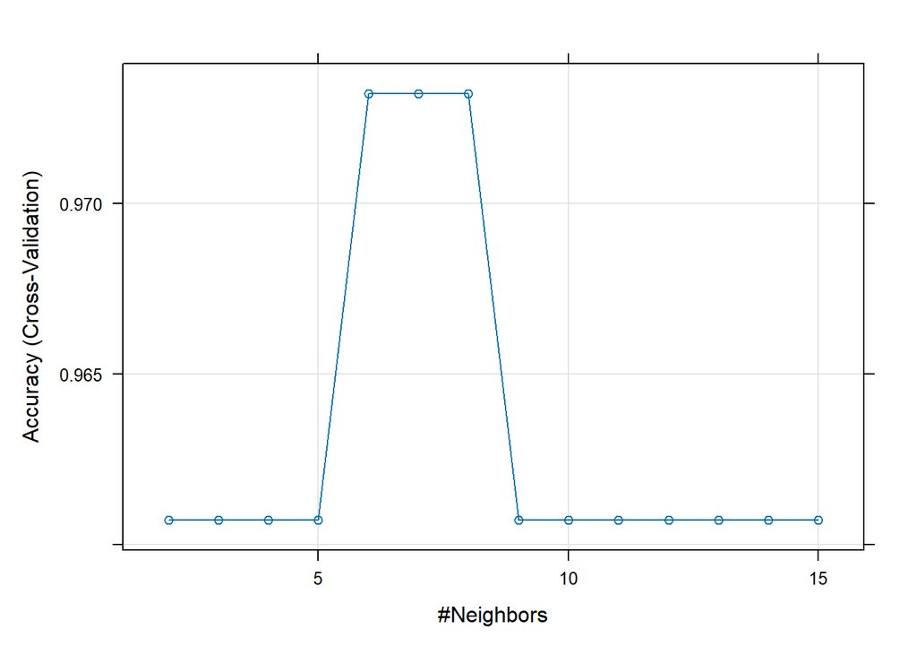

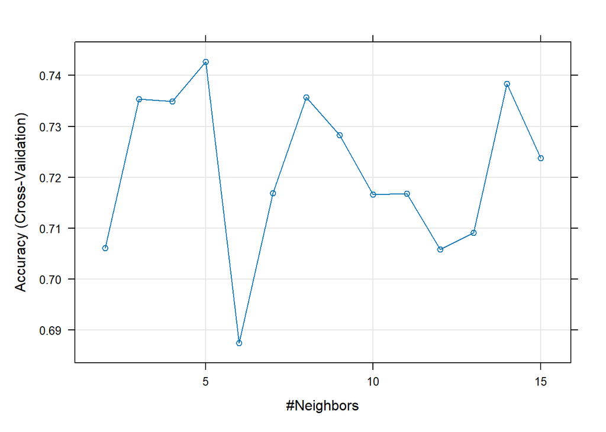

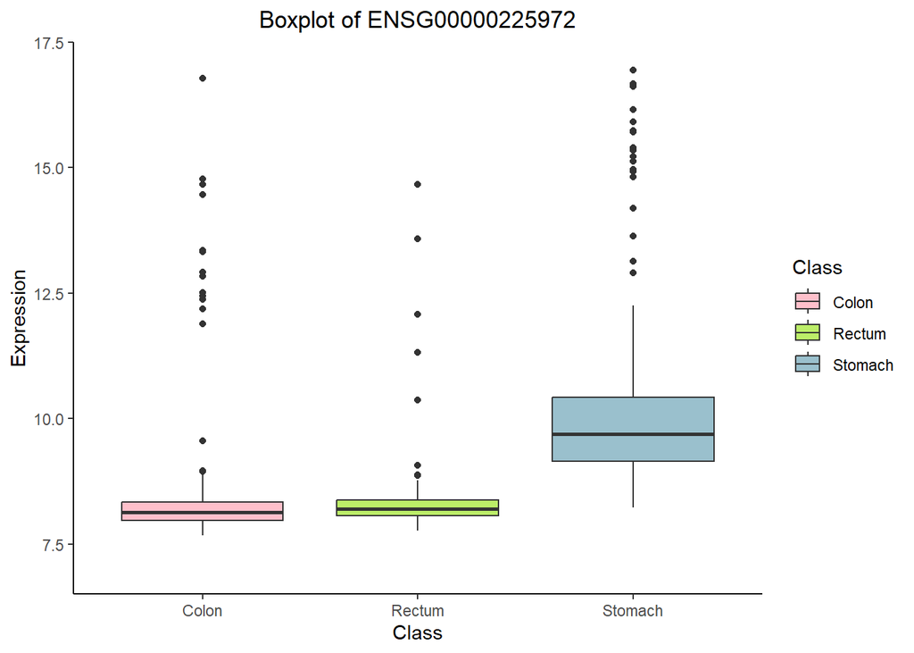

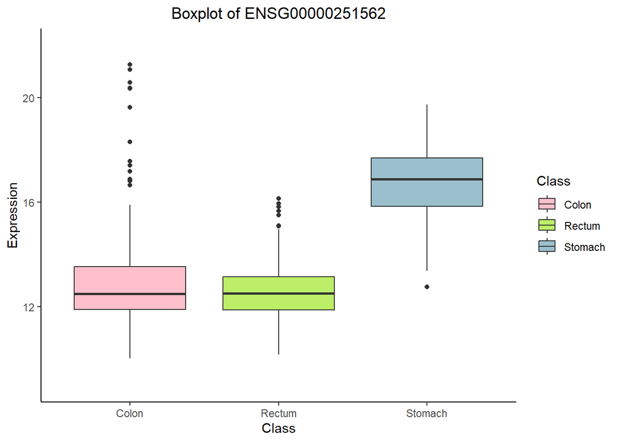

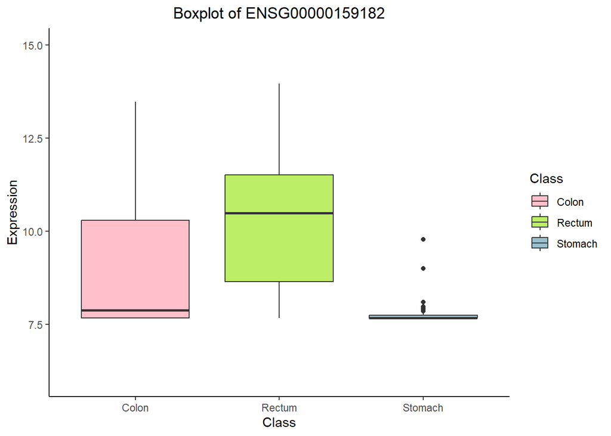

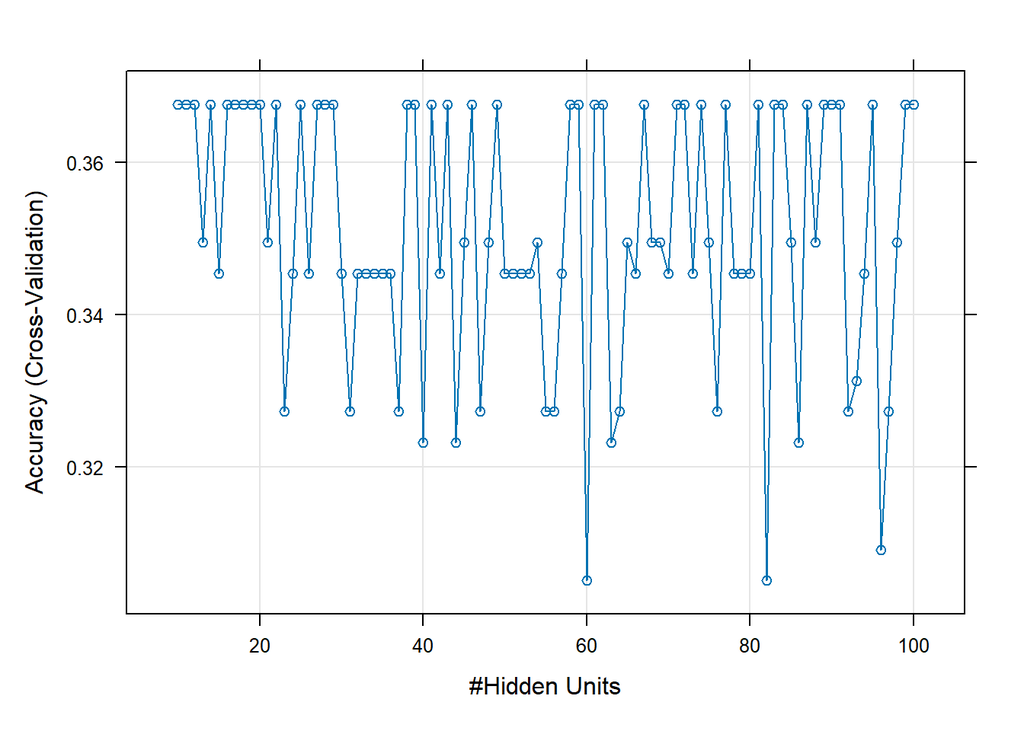